# aDNA damage analysis

# 1. Preparations

# 1.1 Packages

```r
library(scales)
packageVersion('scales')
```

```
## [1] '1.4.0'
```

```r
library(tidyverse)
packageVersion('tidyverse')
```

```
## [1] '2.0.0'
```

```r
library(patchwork)
packageVersion('patchwork')
```

```
## [1] '1.3.2'
```

```r
library(ggrepel)
packageVersion('ggrepel')
```

```
## [1] '0.9.5'
```

```r
library(propagate)
packageVersion('propagate')
```

```
## [1] '1.0.6'
```

```r
library(pROC)
packageVersion('pROC')
```

```
## [1] '1.18.5'
```

```r
library(ppcor)
packageVersion('ppcor')
```

```
## [1] '1.1'
```

# 1.2 Read the data

I worked with a training data set (data) to explore trends and fit models and a test dataset (test_genera) to test the models’ performance

#### Training data

```r
data=read.csv('../00_input/damage_data_core_genera.csv')
```

```r
data_w = pivot_wider(data[,-c(3:4)],
           names_from = tool_param,
           values_from = value )
data_w$mapdamage_1_over_lambda=1/data_w$mapdamage_lambda
data_w$pydamage_1over_p=1/data_w$pydamage_p
data_w$qPCRcopies_per_uL_and_mg_rock=data_w$qPCRcopies_per_uL/data_w$mass_mg
```

#### Test data

```r
test_genera = read_csv("../00_input/damage_data_test_genera.csv")
test_genera_w = pivot_wider(test_genera[,-c(3:4)],
           names_from = tool_param,
           values_from = value )
test_genera_w$qPCRcopies_per_uL_and_mg_rock=test_genera_w$qPCRcopies_per_uL/test_genera_w$mass_mg
```

# 2.Characterization of Pseudobins

## 2.1 Assembly length in pseudo-bins

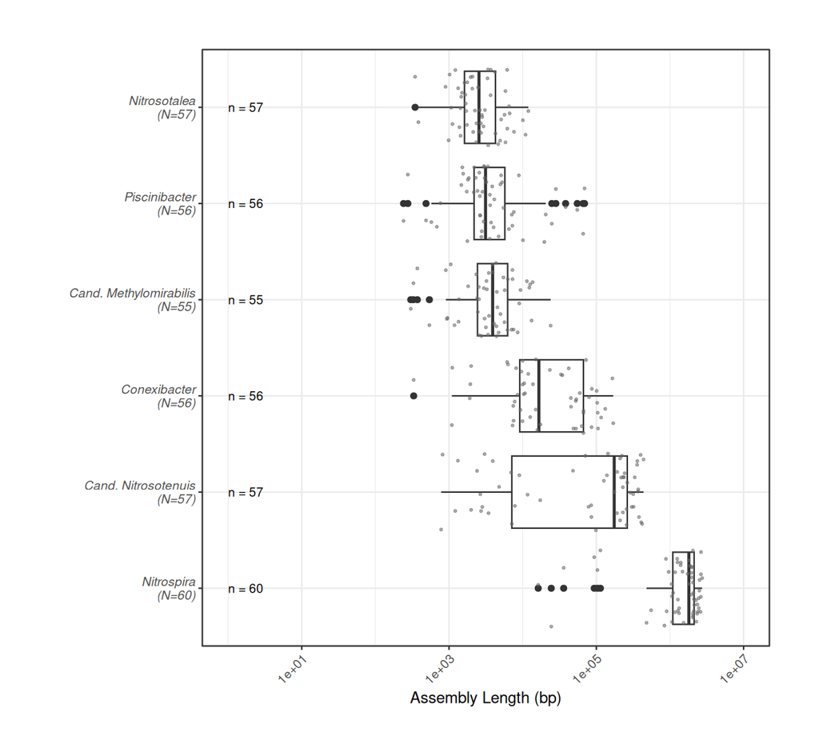

```r
# Calculate sample size per genus
n_data <- data_w %>%
  group_by(genus) %>%
  summarise(N = n())

# Add the sample size as text labels
assembly <- ggplot(data_w,
                   aes(x = factor(genus, levels = c('nitrospira',
                                                    'candidatus_nitrosotenuis',
                                                    'conexibacter',
                                                    'candidatus_methylomirabilis',
                                                    'piscinibacter',
                                                    'nitrosotalea')),
                       y = pydamage_len)) +
  geom_boxplot() +
  geom_jitter(size = 0.5, color = 'gray40', alpha=0.5) +
  scale_y_log10(limits = c(1, 10000000)) +
  theme_bw(base_size = 9) +
  coord_flip(clip = "off") +
  ylab('Assembly Length (bp)') +
  xlab('') +
  theme(axis.text.x = element_text(angle=45, hjust=1, vjust=1),
        axis.text.y = element_text(face = "italic"),plot.margin = margin(1, 1, 1, 1, "cm")) +
  scale_x_discrete(labels = c(
    "candidatus_methylomirabilis" = "Cand. Methylomirabilis\n(N=55)" ,
    "candidatus_nitrosotenuis"  = "Cand. Nitrosotenuis\n(N=57)",
    "conexibacter"  =  "Conexibacter\n(N=56)",
    "nitrosotalea"  ="Nitrosotalea\n(N=57)",
    "nitrospira"="Nitrospira\n(N=60)",
    "piscinibacter" = "Piscinibacter\n(N=56)"
  )) +
   geom_text(
    data = n_data,
    aes(
      x = factor(genus, levels = c(
        "nitrospira",
        "candidatus_nitrosotenuis",
        "conexibacter",
        "candidatus_methylomirabilis",
        "piscinibacter",
        "nitrosotalea"
      )),
      y = 1,                    # position on log10 y-axis
      label = paste0("n = ", N)
    ),
    inherit.aes = FALSE,
    hjust = 0,
    size = 2.5
  )

assembly
```

## 2.2 GC content

```r
gc_over_time <- data_w %>%
group_by(genus) %>%
  mutate(weight_len = log1p(pydamage_len),  # log(1 + len) to handle zeros safely
         weight_len = weight_len / max(weight_len, na.rm = TRUE)) %>%
do({
fit <- lm(gc_gc ~ median_age_yrs_bf_1950, data = .,weights = weight_len)
s <- summary(fit)
# slope = coefficient for age
slope <- coef(s)["median_age_yrs_bf_1950", "Estimate"]
se    <- coef(s)["median_age_yrs_bf_1950", "Std. Error"]
tval  <- coef(s)["median_age_yrs_bf_1950", "t value"]
pval  <- coef(s)["median_age_yrs_bf_1950", "Pr(>|t|)"]
r2    <- s$r.squared
adjr2 <- s$adj.r.squared
data.frame(
slope = slope,
se = se,
tval = tval,
pval = pval,
r2 = r2,
adjr2 = adjr2
)
}) %>%
ungroup() %>%
mutate(p_adj = p.adjust(pval, method = "BH"))
print(gc_over_time)
```

```
## # A tibble: 6 × 8
##   genus                    slope      se   tval    pval      r2    adjr2   p_adj
##   <chr>                    <dbl>   <dbl>  <dbl>   <dbl>   <dbl>    <dbl>   <dbl>
## 1 candidatus_methylomi… -8.26e-8 4.99e-7 -0.166 8.69e-1 5.18e-4 -0.0183  8.98e-1
## 2 candidatus_nitrosote… -4.75e-7 3.59e-7 -1.32  1.91e-1 3.09e-2  0.0133  5.73e-1
## 3 conexibacter          -6.29e-7 1.52e-7 -4.15  1.20e-4 2.42e-1  0.227   7.20e-4
## 4 nitrosotalea          -2.52e-7 3.61e-7 -0.698 4.88e-1 8.77e-3 -0.00925 7.88e-1
## 5 nitrospira            -9.03e-9 6.98e-8 -0.129 8.98e-1 2.88e-4 -0.0169  8.98e-1
## 6 piscinibacter         -3.39e-7 5.30e-7 -0.640 5.25e-1 7.52e-3 -0.0109  7.88e-1
```

```r
#gc_values from literature (min/max)
gc_lit=data.frame(
  piscinibacter=c(0.662, 0.699),
  conexibacter=c(0.7, 0.74),
  nitrosotalea=c(0.371, 0.374),
  nitrospira=c(0.483,0.637),
  candidatus_nitrosotenuis=c(0.41,0.423),
  candidatus_methylomirabilis=c(0.5858, 0.5987)) %>% t() %>% data.frame() %>% rownames_to_column("genus") %>%  mutate(genus_f = factor(genus, levels=c("candidatus_nitrosotenuis","nitrosotalea" , "candidatus_methylomirabilis", "nitrospira" , "piscinibacter", "conexibacter")))
gc_lit
```

| genus | X1 | X2 | genus_f |
| --- | --- | --- | --- |
| piscinibacter | 0.6620 | 0.6990 | piscinibacter |
| conexibacter | 0.7000 | 0.7400 | conexibacter |
| nitrosotalea | 0.3710 | 0.3740 | nitrosotalea |
| nitrospira | 0.4830 | 0.6370 | nitrospira |
| candidatus_nitrosotenuis | 0.4100 | 0.4230 | candidatus_nitrosotenuis |
| candidatus_methylomirabilis | 0.5858 | 0.5987 | candidatus_methylomirabilis |

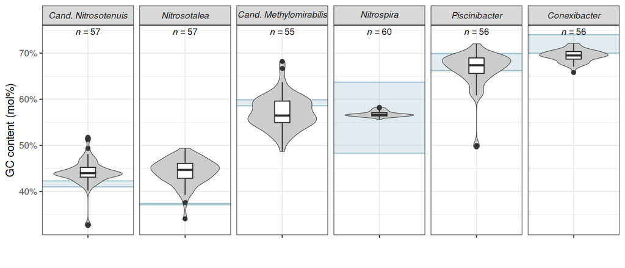

```r
genus_labels <- c(
  "candidatus_methylomirabilis" = "italic('Cand. Methylomirabilis')",
  "candidatus_nitrosotenuis"    = "italic('Cand. Nitrosotenuis')",
  "conexibacter"                = "italic('Conexibacter')",
  "nitrosotalea"                = "italic('Nitrosotalea')",
  "nitrospira"                  = "italic('Nitrospira')",
  "piscinibacter"               = "italic('Piscinibacter')"
)

gc_n <- data_w %>%mutate(genus_f = factor( genus,levels = c("candidatus_nitrosotenuis","nitrosotalea","candidatus_methylomirabilis","nitrospira","piscinibacter","conexibacter"))) %>%
count(genus_f)

gc_plot=data_w %>%
  mutate(genus_f = factor(genus, levels=c("candidatus_nitrosotenuis","nitrosotalea" , "candidatus_methylomirabilis", "nitrospira" , "piscinibacter", "conexibacter"))) %>%
 ggplot(aes(x = '', y = gc_gc)) +
geom_hline(data = gc_lit, aes(yintercept=X1),color='lightblue3') +
geom_hline(data = gc_lit, aes(yintercept=X2),color='lightblue3') +
   geom_rect(data = gc_lit, aes(xmin = -Inf, xmax = Inf, ymin = X1, ymax = X2),
            inherit.aes = FALSE, fill = "lightblue3", alpha = 0.3)+
geom_violin(fill='gray80', linewidth=0.2)+
geom_boxplot(width=0.2)+
facet_wrap(~ genus_f, labeller = labeller(
               genus_f = as_labeller(genus_labels, label_parsed)), nrow=1, ncol=6,drop = FALSE) +
labs(x = "",y = "GC content (mol%)") +
theme_bw(base_size = 9)+
  scale_y_continuous(labels = percent_format(accuracy = 1))+
  geom_text(data = gc_n,aes( x = 1, y = Inf,label = paste0("italic(n) == ", n)),vjust = 1.5,size = 2.5, parse = TRUE)
gc_plot
```

There is no significant temporal trend in GC content, except for Conexibacter, where the GC content is weakly falling with increasing age.

# 3. Correlation analysis

## 3.1 Correlation of parameters with age

I correlated all damage parameters with age but separated by genus to see if the trends are consistent. I chose Spearman correlation because the expected relationship is non-linear.

```r
cor_data = data[data$tool_param %in% c("pydamage_pmin","pydamage_pmax","pydamage_p" ,"mapdamage_delta_d",     "mapdamage_delta_s","mapdamage_lambda","compute_length_mode", "compute_length_geom_p"),] %>%
  group_by(genus, tool_param) %>%
  summarise(
    cor_test = list(cor.test(median_age_yrs_bf_1950,  if(tool_param[1] %in% c("")) 1 / value else value, method = "spearman")),
    .groups = 'drop'
  ) %>%
  mutate(
    estimate = map_dbl(cor_test, ~ .x$estimate),
    p_value = map_dbl(cor_test, ~ .x$p.value)
  )
```

I’m adjusting p-values for multiple testing with the Banjamini-Hochberg method and create labels for plotting

```r
cor_data = cor_data %>%
  mutate(p_adj = p.adjust(p_value, method = "BH")) %>%
  mutate(
    label = sprintf("rho = %.2f\nadj.p = %.3g", estimate, p_adj),
    stars = case_when(
    p_adj <= 0.001 ~ "***",
    p_adj <= 0.01  ~ "**",
    p_adj <= 0.05  ~ "*",
    TRUE          ~ ""),
    label_short = paste0(round(estimate, 2), stars))
```

#### Heatmap

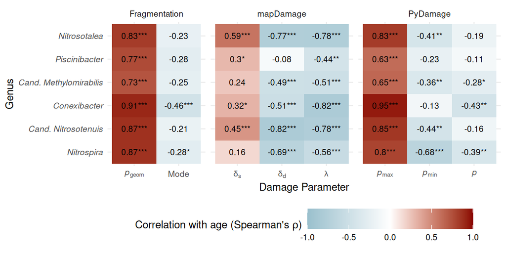

```r
cor= cor_data %>% mutate(class=sub("_.*", "", tool_param)) %>%  ggplot(aes(y=factor(genus, levels=c('nitrospira','candidatus_nitrosotenuis','conexibacter','candidatus_methylomirabilis', 'piscinibacter','nitrosotalea')), x=factor(tool_param,levels=c('compute_length_geom_p','compute_length_mode','mapdamage_delta_s','mapdamage_delta_d','mapdamage_lambda','pydamage_pmax','pydamage_pmin','pydamage_p')), fill=estimate))+
  geom_tile()+
  scale_fill_gradient2(low = "lightblue3", mid = "white", high = "darkred", midpoint = 0, limits = c(-1, 1))+
  geom_text(aes(label = label_short), color = "black", size = 2.5)+
  scale_x_discrete(labels = c("pydamage_p" = expression(italic(p)) ,
                               "pydamage_pmin" = expression(italic(p)[min]),
                                "mapdamage_delta_s" = expression(italic(delta)[s]),
                               "compute_length_mode" ="Mode",
                               "mapdamage_lambda"=expression(italic(lambda)),
                               "mapdamage_delta_d" = expression(italic(delta)[d]),
                               "compute_length_geom_p" =expression(italic(p)[geom]),
                               "pydamage_pmax"=expression(italic(p)[max])))+
  scale_y_discrete(labels = c("candidatus_methylomirabilis" = "Cand. Methylomirabilis" ,
                              "candidatus_nitrosotenuis"  = "Cand. Nitrosotenuis",
                               "conexibacter"  =  "Conexibacter",
                               "nitrosotalea"  ="Nitrosotalea",
                               "nitrospira"="Nitrospira",
                               "piscinibacter" = "Piscinibacter"))+
   facet_grid(. ~ class, scales="free_x", space="free", labeller=labeller(class=c('compute'='Fragmentation', 'mapdamage'='mapDamage', 'pydamage'='PyDamage')))+
  theme_minimal(base_size = 9)+
  theme( legend.position = 'bottom', axis.text.y=element_text(face = "italic"),  legend.key.width = unit(1, "cm"))+
   labs(
    y = 'Genus',
    x = 'Damage Parameter',
    fill = expression(paste("Correlation with age (Spearman's ", italic(rho), ")")))
cor
```

#### Scatterplot

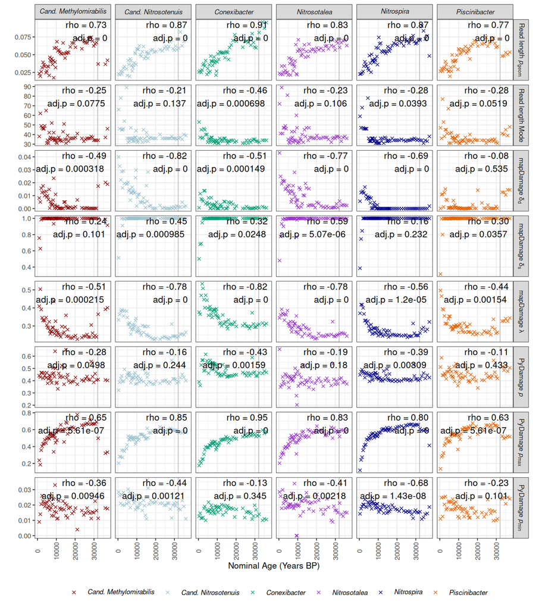

```r
#Helper function for the labels
tool_param_labels <- c(
  "pydamage_p" = "'PyDamage'~italic(p)",
  "pydamage_pmin" = "'PyDamage'~italic(p)[min]",
  "mapdamage_delta_s" = "'mapDamage'~italic(delta)[s]",
  "compute_length_mode" = "'Read length'~Mode",
  "mapdamage_lambda" = "'mapDamage'~italic(lambda)",
  "mapdamage_delta_d" = "'mapDamage'~italic(delta)[d]",
  "compute_length_geom_p" = "'Read length'~italic(p)[geom]",
  "pydamage_pmax" = "'PyDamage'~italic(p)[max]"
)

# Named vector of labels for genus (plain text)
genus_labels <- c(
  "candidatus_methylomirabilis" = "italic('Cand. Methylomirabilis')",
  "candidatus_nitrosotenuis"    = "italic('Cand. Nitrosotenuis')",
  "conexibacter"                = "italic('Conexibacter')",
  "nitrosotalea"                = "italic('Nitrosotalea')",
  "nitrospira"                  = "italic('Nitrospira')",
  "piscinibacter"               = "italic('Piscinibacter')"
)

scatter_cor=
data[data$tool_param %in% c("pydamage_pmin","pydamage_pmax","pydamage_p" ,"mapdamage_delta_d",     "mapdamage_delta_s","mapdamage_lambda","compute_length_mode", "compute_length_geom_p"),] %>% mutate(
    value_plot = ifelse(tool_param %in% c(""), 1 / value, value)
  ) %>%
ggplot(aes(x = median_age_yrs_bf_1950, y = value_plot, color = genus)) +
  geom_vline(xintercept=32000, color="gray75")+
  geom_point(shape=4) +
 facet_grid(rows = vars(tool_param), cols = vars(genus),
             scales = "free_y",
             labeller = labeller(
               tool_param = as_labeller(tool_param_labels, label_parsed),
               genus = as_labeller(genus_labels, label_parsed)
             )) +
  theme_bw(base_size = 8) +
  theme(axis.text.x = element_text(angle = 90, vjust = 0.5),legend.position = 'bottom') +
  geom_text(size=3,
    data = cor_data,
    aes(label = label),
    x = Inf, y = Inf,
    hjust = 1.1, vjust = 1.1,
    inherit.aes = FALSE
  )+
  xlab('Nominal Age (Years BP)')+
  ylab('')+
  scale_color_manual("", values =c( "darkred","lightblue3",'#009E73',"darkorchid", "blue4", '#E66101'),guide = guide_legend(ncol = 6),   labels = parse(text = genus_labels)
)
scatter_cor
```

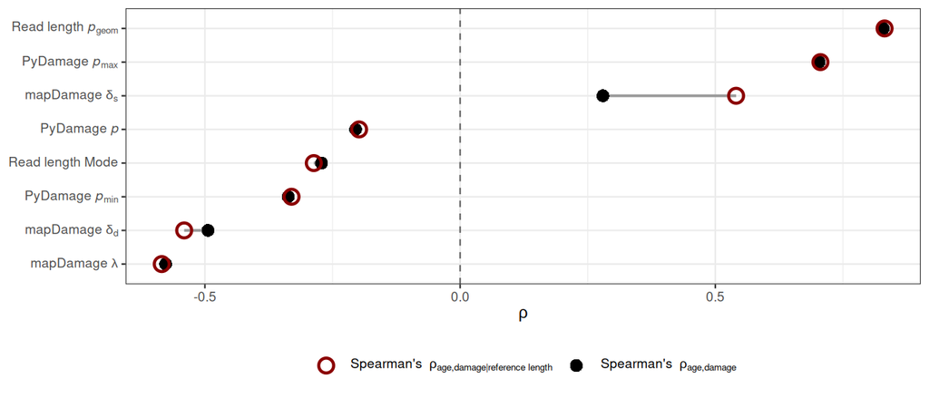

```r
damage_params <- c(
  "pydamage_pmin",
  "pydamage_pmax",
  "pydamage_p",
  "mapdamage_delta_d",
  "mapdamage_delta_s",
  "mapdamage_lambda",
  "compute_length_mode",
  "compute_length_geom_p"
)

wide_data <- data %>%
  filter(tool_param %in% c(damage_params, "pydamage_len")) %>%
  dplyr::select(
    sample_name,
    median_age_yrs_bf_1950,
    tool_param,
    value,
    genus
  ) %>%
  pivot_wider(
    names_from = tool_param,
    values_from = value
  ) %>%
  mutate(
    across(
      all_of(c(damage_params, "pydamage_len")),
      as.numeric
    )
  )

global_cor_data <- map_dfr(
  damage_params,
  function(param) {

    spearman_test <- cor.test(
      x = wide_data$median_age_yrs_bf_1950,
      y = wide_data[[param]],
      method = "spearman"
    )

    partial_test <- pcor.test(
      x = wide_data$median_age_yrs_bf_1950,
      y = wide_data[[param]],
      z = wide_data$pydamage_len,
      method = "spearman"
    )

    tibble(
      tool_param = param,

      spearman_rho = unname(spearman_test$estimate),
      spearman_p = spearman_test$p.value,

      partial_rho = partial_test$estimate,
      partial_p = partial_test$p.value,

      delta_rho = partial_test$estimate - spearman_test$estimate
    )

  }
)
plot_data <- global_cor_data %>%
  tidyr::pivot_longer(cols = c(spearman_rho, partial_rho),  names_to = "correlation_type",values_to = "rho") %>%
  mutate(correlation_type = recode(correlation_type,spearman_rho = "Spearman",partial_rho = "Partial Spearman"))

comparison= ggplot(global_cor_data, aes(y = reorder(tool_param, spearman_rho))) +
 # connecting lines
  geom_segment(aes(x = spearman_rho,xend = partial_rho,yend = reorder(tool_param, spearman_rho)),linewidth = 0.7,color = "grey60") +
# standard Spearman: filled black points
  geom_point( aes(x = spearman_rho, shape = "Spearman"),size = 3,color = "black",fill = "black") +
# partial Spearman: open red circles
  geom_point(aes(x = partial_rho, shape = "Partial Spearman"),size = 3, color = "darkred", stroke = 1.2 ) +
geom_vline(xintercept = 0, linetype = "dashed", color = "grey40") +
scale_shape_manual(name = NULL,values = c("Spearman" = 16,"Partial Spearman" = 21),
  labels = c("Spearman"=expression("Spearman's "~rho[age*","*damage]),
  "Partial Spearman"= expression("Spearman's "~rho[age*","*damage*"|"*reference~length]))) +
labs( x = expression(rho),y = NULL) +
theme_bw(base_size = 9) +
theme(legend.position = "bottom")+
scale_y_discrete(labels = function(x) parse(text = tool_param_labels[x]))
comparison
```

## 3.2 correlation of parameters with each other

### 3.2.1 Fragment length and 1/lambda

```r
cor.test(data_w$compute_length_geom_p, data_w$mapdamage_1_over_lambda, method='spearman' )
```

```
##
##  Spearman's rank correlation rho
##
## data:  data_w$compute_length_geom_p and data_w$mapdamage_1_over_lambda
## S = 2441066, p-value < 2.2e-16
## alternative hypothesis: true rho is not equal to 0
## sample estimates:
##       rho
## 0.6306217
```

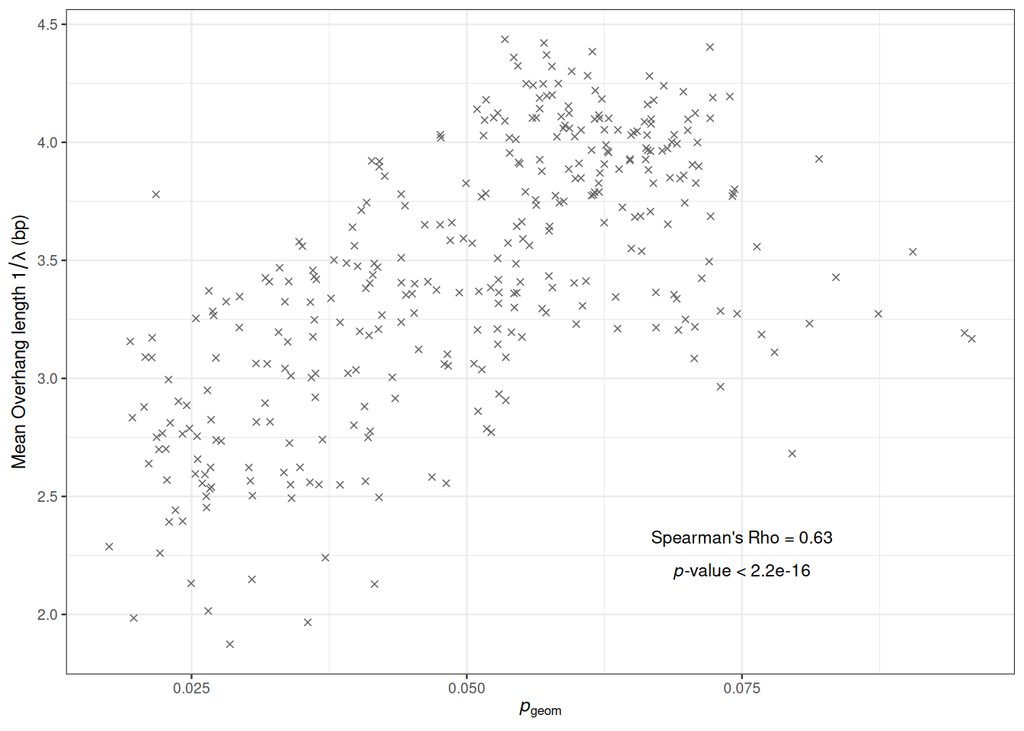

```r
p_cor=ggplot(data_w, aes(y=mapdamage_1_over_lambda, x=compute_length_geom_p))+
  geom_point(shape=4, color='gray40')+
  theme_bw(base_size = 9)+
   labs( y=expression("Mean Overhang length "* 1/italic(lambda)*" (bp)"),  x = expression(italic(p)[geom]))+
   annotate('text', x = 0.075, y = 2.25, label = "atop('Spearman\\'s Rho = 0.63', italic(p)*'-value < 2.2e-16')",,
  parse = TRUE, size=3)
p_cor
```

### 3.2.3 p and lambda

```r
cor.test(data_w$pydamage_p, data_w$mapdamage_lambda, method='spearman' )
```

```
##
##  Spearman's rank correlation rho
##
## data:  data_w$pydamage_p and data_w$mapdamage_lambda
## S = 2658633, p-value < 2.2e-16
## alternative hypothesis: true rho is not equal to 0
## sample estimates:
##       rho
## 0.5976999
```

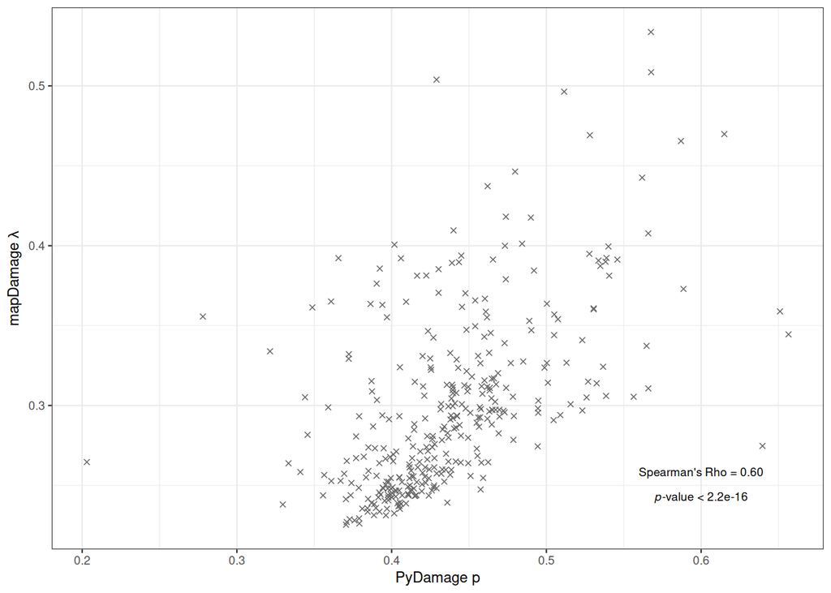

```r
ggplot(data_w, aes(y=mapdamage_lambda, x=pydamage_p))+
  geom_point(shape=4, color='gray40')+
  theme_bw(base_size = 9)+
   labs( y=expression("mapDamage "* lambda),  x = "PyDamage p")+
   annotate('text', x = 0.6, y = 0.25,label = "atop('Spearman\\'s Rho = 0.60', italic(p)*'-value < 2.2e-16')",,
  parse = TRUE, size=2.5)
```

# 4. Exponential saturation models: Damage over time

## 4.1 delta_s over time

### 4.1.1 Fit

```r
plottable_delta_s=data_w[data_w$median_age_yrs_bf_1950<32000,c('median_age_yrs_bf_1950', 'mapdamage_delta_s', 'genus','sample','gc_gc','pydamage_len','pydamage_nb_contigs', 'pydamage_nb_reads')]
fit_delta_s <- nls(mapdamage_delta_s  ~ 1 - exp(-r * median_age_yrs_bf_1950),data = plottable_delta_s,start = list(r = 1e-3))
summary(fit_delta_s)
```

```
##
## Formula: mapdamage_delta_s ~ 1 - exp(-r * median_age_yrs_bf_1950)
##
## Parameters:
##    Estimate Std. Error t value Pr(>|t|)
## r 1.503e-03  3.596e-05   41.78   <2e-16 ***
## ---
## Signif. codes:  0 '***' 0.001 '**' 0.01 '*' 0.05 '.' 0.1 ' ' 1
##
## Residual standard error: 0.03187 on 312 degrees of freedom
##
## Number of iterations to convergence: 6
## Achieved convergence tolerance: 8.924e-07
```

### 4.1.2 Confidence and Prediction interval

```r
# Prediction interval (new observation)
PI_delta_s <- predictNLS(fit_delta_s,
                     newdata =data.frame(median_age_yrs_bf_1950=plottable_delta_s$median_age_yrs_bf_1950),interval = "prediction",alpha = 0.05,nsim = 10000)$summary
CI_delta_s <- predictNLS(fit_delta_s,newdata =data.frame(median_age_yrs_bf_1950=plottable_delta_s$median_age_yrs_bf_1950),interval = "confidence",alpha = 0.05,nsim = 10000)$summary
```

### 4.1.3 Plot

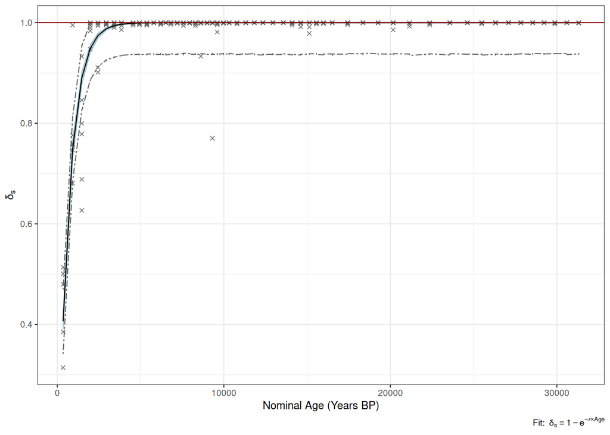

```r
plottable_delta_s$PI_lower <- PI_delta_s[, "Sim.2.5%"]
plottable_delta_s$PI_upper <- PI_delta_s[, "Sim.97.5%"]
plottable_delta_s$CI_lower <- CI_delta_s[, "Sim.2.5%"]
plottable_delta_s$CI_upper <- CI_delta_s[, "Sim.97.5%"]
plottable_delta_s$fitted <- predict(fit_delta_s)
plottable_delta_s$residual=residuals(fit_delta_s)

p_deltas=ggplot(plottable_delta_s, aes(x = median_age_yrs_bf_1950)) +
  geom_line(aes(y = PI_lower),,color='gray40',linetype='twodash')+
  geom_line(aes(y= pmin(pmax(PI_upper, 0), 1)),color='gray40',linetype='twodash')+
  geom_ribbon(aes(x = median_age_yrs_bf_1950,
                  ymin = CI_lower, ymax = CI_upper), fill = "lightblue3", color='lightblue3', alpha=0.5) +
  geom_point(aes(x = median_age_yrs_bf_1950, y = mapdamage_delta_s),color = "gray40", shape = 4) +
  geom_line(aes(x = median_age_yrs_bf_1950, y = fitted), color = "black") +
  labs( x = "Nominal Age (Years BP)", y = expression(italic(delta)[s]),caption= expression("Fit: "~italic(delta)[s] == 1 - e^{-italic(r) %*% Age}) )+
  geom_hline(yintercept=1, colour='darkred')+
  theme_bw(base_size=9)

p_deltas
```

### 4.1.4 Characteristic values

```r
# time to saturation (99%)
(-1/coef(fit_delta_s)['r'])*log(0.01)
```

```
##        r
## 3064.908
```

### 4.1.5 Residuals

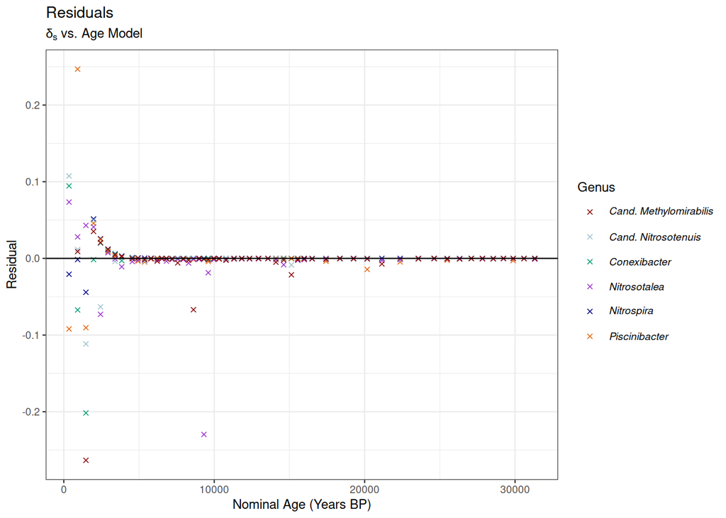

```r
delta_s_res=ggplot(plottable_delta_s, aes(x=median_age_yrs_bf_1950, y=residual, color=genus))+
geom_point(shape=4)+
geom_hline(yintercept=0)+
theme_bw(base_size = 9)+
labs(x='Nominal Age (Years BP)', y='Residual', title='Residuals', subtitle=expression(italic(delta)[s]*' vs. Age Model'))+
scale_color_manual("Genus", values =c( "darkred",   "lightblue3",    '#009E73',    "darkorchid",   "blue4",'#E66101'),
                    labels =parse(text = genus_labels))
delta_s_res
```

## 4.2 pmax over time

### 4.2.1 Fit

```r
plottable_pmax=data_w[data_w$median_age_yrs_bf_1950<32000,c('median_age_yrs_bf_1950', 'pydamage_pmax','genus', 'sample', 'gc_gc','pydamage_len','pydamage_nb_contigs', 'pydamage_nb_reads')]
# Fit the model using nls
fit_pmax <- nls(pydamage_pmax  ~ a+b * (1 - exp(-r * median_age_yrs_bf_1950)),
data = plottable_pmax,
start = list(r = 1e-4, b=0.6,a=0.2))
summary(fit_pmax)
```

```
##
## Formula: pydamage_pmax ~ a + b * (1 - exp(-r * median_age_yrs_bf_1950))
##
## Parameters:
##    Estimate Std. Error t value Pr(>|t|)
## r 1.704e-04  1.294e-05   13.17   <2e-16 ***
## b 4.034e-01  1.535e-02   26.29   <2e-16 ***
## a 2.022e-01  1.628e-02   12.42   <2e-16 ***
## ---
## Signif. codes:  0 '***' 0.001 '**' 0.01 '*' 0.05 '.' 0.1 ' ' 1
##
## Residual standard error: 0.05847 on 310 degrees of freedom
##
## Number of iterations to convergence: 8
## Achieved convergence tolerance: 9.087e-06
```

### 4.2.2 Confidence and Prediction intervals

```r
# Confidence interval (mean curve)
CI_pmax = predictNLS(fit_pmax, newdata = data.frame(median_age_yrs_bf_1950=plottable_pmax$median_age_yrs_bf_1950 ), interval = "confidence", alpha = 0.05, nsim = 10000)$summary

# Prediction interval (new observation)
PI_pmax= predictNLS(fit_pmax, newdata =data.frame(median_age_yrs_bf_1950=plottable_pmax$median_age_yrs_bf_1950), interval = "prediction", alpha = 0.05, nsim = 10000)$summary
```

### 4.2.3 Plot

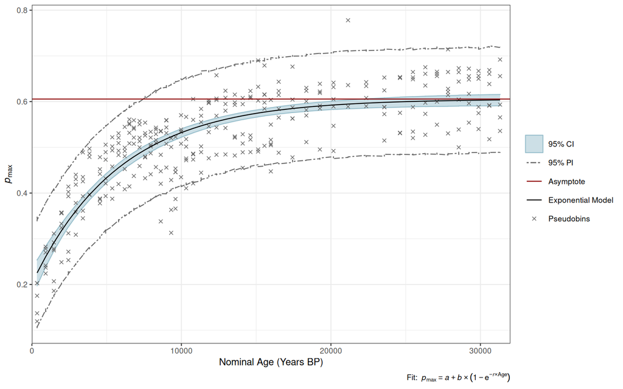

```r
plottable_pmax$fitted <- predict(fit_pmax)
plottable_pmax$residual=residuals(fit_pmax)
plottable_pmax$CI_lower <- CI_pmax[, "Sim.2.5%"]
plottable_pmax$CI_upper <- CI_pmax[, "Sim.97.5%"]
plottable_pmax$PI_lower <- PI_pmax[, "Sim.2.5%"]
plottable_pmax$PI_upper <- PI_pmax[, "Sim.97.5%"]

p_pmax= ggplot(plottable_pmax, aes(x = median_age_yrs_bf_1950)) +
  geom_line(aes(y = PI_lower,color='95% PI'),linetype='twodash')+
  geom_line(aes(y= PI_upper,color='95% PI'),linetype='twodash')+
  geom_ribbon(aes(x = median_age_yrs_bf_1950,
                  ymin = CI_lower, ymax = CI_upper, color='95% CI' ),fill = "lightblue3", alpha=0.5) +
geom_point(aes(x = median_age_yrs_bf_1950, y = pydamage_pmax, colour='Pseudobins'), shape=4) +
geom_line(aes(x = median_age_yrs_bf_1950, y = fitted, color='Exponential Model'))+
geom_hline(aes(yintercept= coef(fit_pmax)["a"]+coef(fit_pmax)['b'], colour='Asymptote'))+
scale_color_manual(name = "",values = c('Asymptote'='darkred','Exponential Model'='black','95% PI' = 'gray40', '95% CI'='lightblue3', 'Pseudobins'='gray40' ))+
theme_bw(base_size=9)+
scale_x_continuous(expand = c(0,0), limits=c(0,32000))+
labs(
caption = expression("Fit: "~
italic(p)[max] == italic(a) + italic(b) %*% (1 - e^{italic(-r) %*% Age})) ,y=expression(italic(p)[max]), x = "Nominal Age (Years BP)")
p_pmax
```

### 4.2.4 characteristic values

```r
# 99% saturation time (-1/r)*log(1-0.99)
(-1/coef(fit_pmax)['r'])*log(0.01)
```

```
##        r
## 27018.66
```

```r
#saturation value
coef(fit_pmax)['b']+coef(fit_pmax)["a"]
```

```
##         b
## 0.6056128
```

### 4.2.5 Residuals

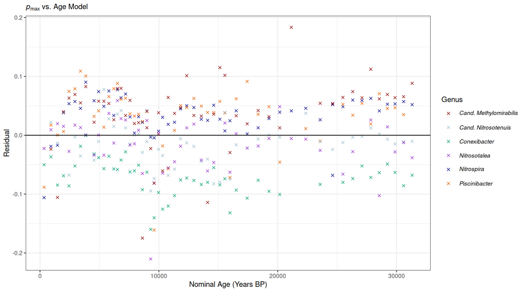

```r
pmax_res=ggplot(plottable_pmax, aes(x=median_age_yrs_bf_1950, y=residual, color=genus))+
geom_point(shape=4)+
geom_hline(yintercept=0)+
theme_bw(base_size = 9)+
labs(x='Nominal Age (Years BP)', y='Residual',subtitle=expression(italic(p)[max]*' vs. Age Model'))+
scale_color_manual("Genus", values =c( "darkred",   "lightblue3",    '#009E73',    "darkorchid",   "blue4",'#E66101'),
                  labels = parse(text = genus_labels))
pmax_res
```

## 4.3 p_geom over time

### 4.3.1 Fit

```r
plottable_pgeom <- data_w[data_w$median_age_yrs_bf_1950<32000,c('median_age_yrs_bf_1950', 'compute_length_geom_p', 'genus', 'sample','gc_gc','pydamage_len','pydamage_nb_contigs', 'pydamage_nb_reads')]

fit_pgeom<- nls(compute_length_geom_p ~ a+ b * (1 - exp(-r * median_age_yrs_bf_1950)),
data = plottable_pgeom,
start = list(b = 0.12, r = 0.0001, a=0.02),
control = nls.control(maxiter = 100, warnOnly = FALSE))
# Summary of fit
summary(fit_pgeom)
```

```
##
## Formula: compute_length_geom_p ~ a + b * (1 - exp(-r * median_age_yrs_bf_1950))
##
## Parameters:
##    Estimate Std. Error t value Pr(>|t|)
## b 5.597e-02  2.490e-03  22.483  < 2e-16 ***
## r 6.724e-05  8.672e-06   7.753  1.3e-13 ***
## a 1.940e-02  1.635e-03  11.867  < 2e-16 ***
## ---
## Signif. codes:  0 '***' 0.001 '**' 0.01 '*' 0.05 '.' 0.1 ' ' 1
##
## Residual standard error: 0.007879 on 310 degrees of freedom
##
## Number of iterations to convergence: 7
## Achieved convergence tolerance: 1.653e-06
```

### 4.3.2 Confidence and Predcition intervals

```r
# Confidence interval (mean curve)
CI_pgeom = predictNLS(fit_pgeom, newdata = data.frame(median_age_yrs_bf_1950=plottable_pgeom$median_age_yrs_bf_1950 ), interval = "confidence", alpha = 0.05, nsim = 10000)$summary

# Prediction interval (new observation)
PI_pgeom= predictNLS(fit_pgeom, newdata =data.frame(median_age_yrs_bf_1950=plottable_pgeom$median_age_yrs_bf_1950), interval = "prediction", alpha = 0.05, nsim = 10000)$summary
```

### 4.3.3 Plot

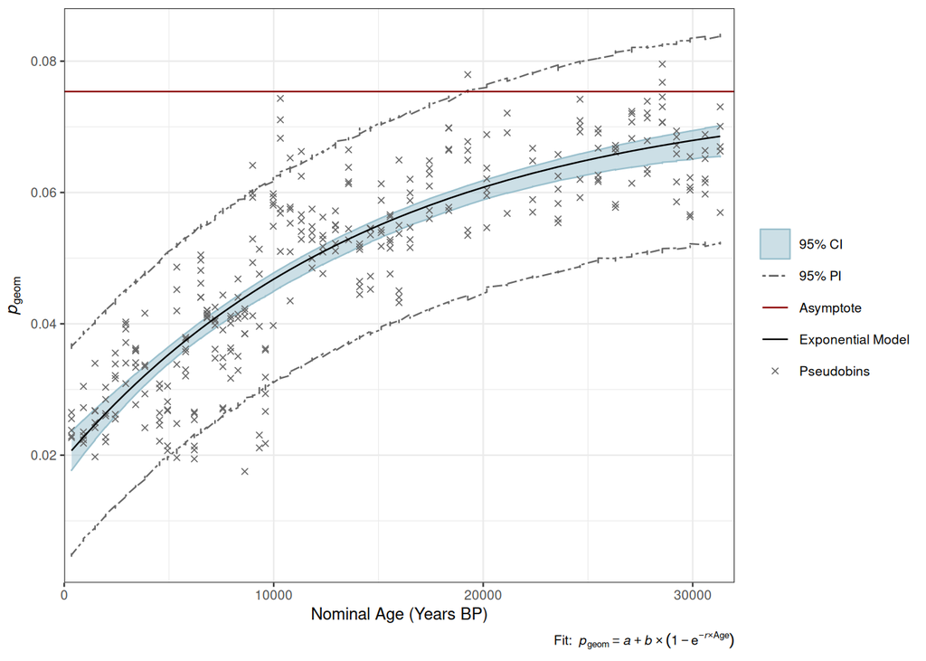

```r
plottable_pgeom$fitted <- predict(fit_pgeom)
plottable_pgeom$residual= residuals(fit_pgeom)
plottable_pgeom$CI_lower <- CI_pgeom[, "Sim.2.5%"]
plottable_pgeom$CI_upper <- CI_pgeom[, "Sim.97.5%"]
plottable_pgeom$PI_lower <- PI_pgeom[, "Sim.2.5%"]
plottable_pgeom$PI_upper <- PI_pgeom[, "Sim.97.5%"]

  p_pgeom=ggplot(plottable_pgeom, aes(x=median_age_yrs_bf_1950))+
  geom_line(aes(y = PI_lower,color='95% PI'),linetype='twodash')+
  geom_line(aes(y= PI_upper,color='95% PI'),linetype='twodash')+
  geom_ribbon(aes(x = median_age_yrs_bf_1950,
                  ymin = CI_lower, ymax = CI_upper, color= '95% CI'), fill = "lightblue3", alpha=0.5) +
geom_point(aes(x=median_age_yrs_bf_1950, y=compute_length_geom_p,color='Pseudobins'), shape=4)+
geom_line(aes(x=median_age_yrs_bf_1950, y=fitted, color='Exponential Model'))+
geom_hline( aes(yintercept=coef(fit_pgeom)['b']+coef(fit_pgeom)['a'],colour='Asymptote'))+
theme_bw(base_size = 9)+
scale_color_manual(name = "",values = c('Asymptote'='darkred','Exponential Model'='black','95% PI' = 'gray40', '95% CI'='lightblue3', 'Pseudobins'='gray40' ))+
scale_x_continuous(expand = c(0,0), limits=c(0,32000))+
labs(
caption = expression("Fit: "~
italic(p)[geom] == italic(a) + italic(b) %*% (1 - e^{italic(-r) %*% Age})) ,y=expression(italic(p)[geom]), x = "Nominal Age (Years BP)")
p_pgeom
```

### 4.3.4 Characteristic values

```r
#saturation value p_inf+a
coef(fit_pgeom)['b']+coef(fit_pgeom)['a']
```

```
##          b
## 0.07537488
```

```r
# 99% saturation time (-1/r)*log(1-0.99)
(-1/coef(fit_pgeom)['r'])*log(0.01)
```

```
##        r
## 68487.38
```

### 4.3.5 Residuals

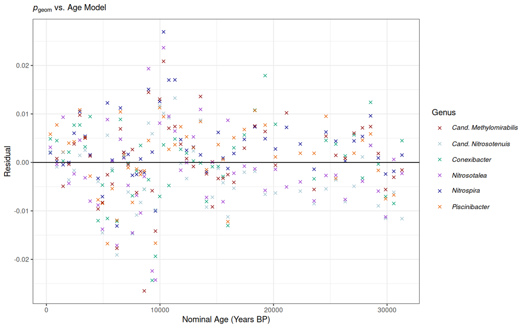

```r
p_geom_res=ggplot(plottable_pgeom, aes(x=median_age_yrs_bf_1950, y=residual, color=genus))+
geom_point(shape=4)+
geom_hline(yintercept=0)+
theme_bw(base_size = 9)+
labs(x='Nominal Age (Years BP)', y='Residual',subtitle=expression(italic(p)[geom]*' vs. Age Model'))+
scale_color_manual("Genus", values =c( "darkred",   "lightblue3",    '#009E73',    "darkorchid",   "blue4",'#E66101'),
                  labels = parse(text = genus_labels))
p_geom_res
```

## 4.4 length mode over time

### 4.4.1 Fit

```r
plottable_mode <- data_w[data_w$median_age_yrs_bf_1950<32000,c('median_age_yrs_bf_1950', 'compute_length_mode', 'genus', 'sample', 'gc_gc','pydamage_len','pydamage_nb_contigs', 'pydamage_nb_reads')]

fit_mode <- nls(
compute_length_mode ~ Lmin + (L0 - Lmin) * exp(-lambda * median_age_yrs_bf_1950),
data = plottable_mode,
start = list(L0 = 70, Lmin = 30, lambda = 0.0001))

summary(fit_mode)
```

```
##
## Formula: compute_length_mode ~ Lmin + (L0 - Lmin) * exp(-lambda * median_age_yrs_bf_1950)
##
## Parameters:
##         Estimate Std. Error t value Pr(>|t|)
## L0     6.093e+01  2.606e+00  23.384  < 2e-16 ***
## Lmin   3.453e+01  6.242e-01  55.310  < 2e-16 ***
## lambda 2.864e-04  4.372e-05   6.552 2.36e-10 ***
## ---
## Signif. codes:  0 '***' 0.001 '**' 0.01 '*' 0.05 '.' 0.1 ' ' 1
##
## Residual standard error: 7.236 on 310 degrees of freedom
##
## Number of iterations to convergence: 11
## Achieved convergence tolerance: 3.421e-06
```

### 4.4.2 Confidence and Prediction Intervals

```r
# Confidence interval (mean curve)
CI_mode = predictNLS(fit_mode, newdata = data.frame(median_age_yrs_bf_1950=plottable_mode$median_age_yrs_bf_1950 ), interval = "confidence", alpha = 0.05, nsim = 10000)$summary

# Prediction interval (new observation)
PI_mode= predictNLS(fit_mode, newdata =data.frame(median_age_yrs_bf_1950=plottable_mode$median_age_yrs_bf_1950), interval = "prediction", alpha = 0.05, nsim = 10000)$summary
```

### 4.4.3 Plot

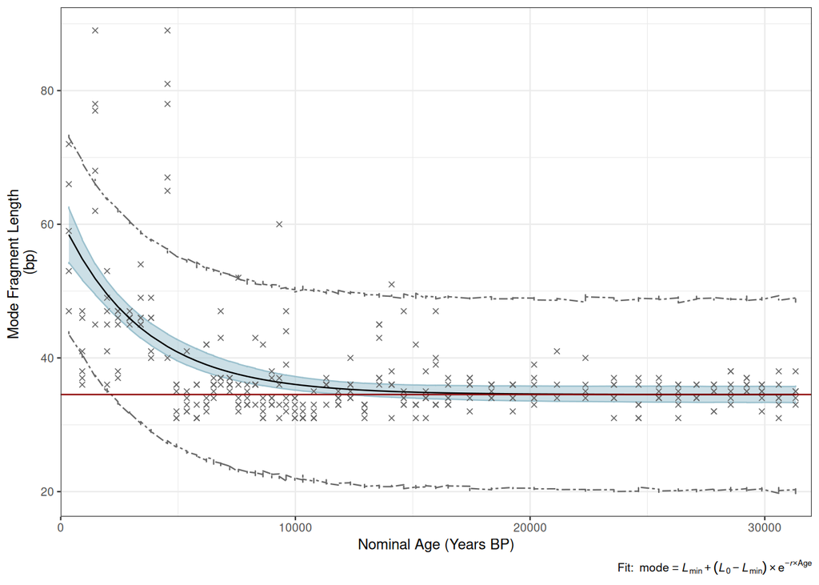

```r
plottable_mode$fitted <- predict(fit_mode)
plottable_mode$residual=residuals(fit_mode)
plottable_mode$CI_lower <- CI_mode[, "Sim.2.5%"]
plottable_mode$CI_upper <- CI_mode[, "Sim.97.5%"]

plottable_mode$PI_lower <- PI_mode[, "Sim.2.5%"]
plottable_mode$PI_upper <- PI_mode[, "Sim.97.5%"]

p_mode =ggplot(plottable_mode, aes(x = median_age_yrs_bf_1950)) +
   geom_line(aes(y = PI_lower),color="gray40",linetype='twodash')+
  geom_line(aes(y= PI_upper),color="gray40",linetype='twodash')+
  geom_ribbon(aes(x = median_age_yrs_bf_1950,
                  ymin = CI_lower, ymax = CI_upper), fill = "lightblue3", color='lightblue3', alpha=0.5) +
geom_point(aes(y = compute_length_mode), color = "gray40", shape=4) +
geom_line(aes(y = fitted), color = "black") +
labs(x = "Nominal Age (Years BP)", y = "Mode Fragment Length \n(bp)", caption = expression("Fit: "~
mode == italic(L)[min]+(italic(L)[0]-italic(L)[min]) %*%  e^{italic(-r) %*% Age}) ) +
geom_hline(yintercept = coef(fit_mode)['Lmin'],  color = "darkred") +
theme_bw(base_size=9)+
scale_x_continuous(expand = c(0,0), limits=c(0,32000))
p_mode
```

### 4.4.4 Characterisitc Values

```r
#time to reach 99% saturation
(-1/coef(fit_mode)['lambda'])*log(0.01)
```

```
##   lambda
## 16077.48
```

### 4.4.5 Residuals

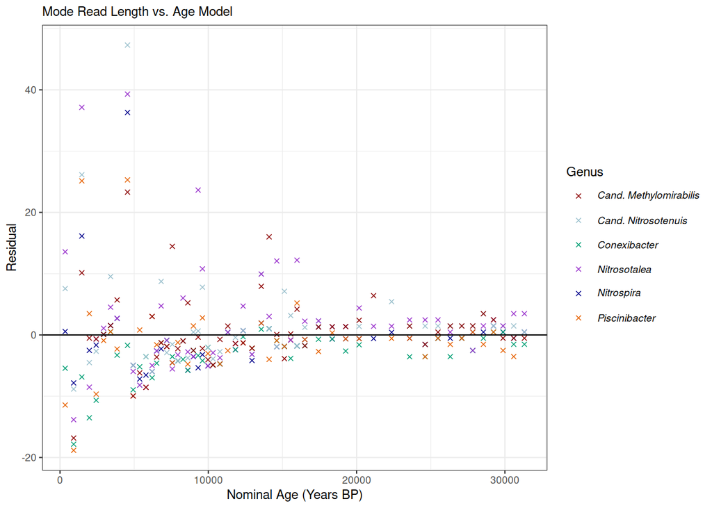

```r
mode_res=ggplot(plottable_mode, aes(x=median_age_yrs_bf_1950, y=residual, color=genus))+
geom_point(shape=4)+
geom_hline(yintercept=0)+
theme_bw(base_size = 9)+
labs(x='Nominal Age (Years BP)', y='Residual',subtitle='Mode Read Length vs. Age Model')+
scale_color_manual("Genus", values =c( "darkred",   "lightblue3",    '#009E73',    "darkorchid",   "blue4",'#E66101'),
                  labels = parse(text = genus_labels))
mode_res
```

## 4.5 1/lambda over age - mean overhang length

### 4.5.1 Fit

```r
plottable_overhangs <- data_w[data_w$median_age_yrs_bf_1950<32000,c('median_age_yrs_bf_1950', 'mapdamage_lambda', 'genus', 'sample', 'gc_gc','pydamage_len','pydamage_nb_contigs', 'pydamage_nb_reads')]

fit_overhangs <- nls(1/mapdamage_lambda ~ a+ b * (1 - exp(-r * median_age_yrs_bf_1950)),
data = plottable_overhangs,
start = list(b = 2, r = 0.0001, a=2),
control = nls.control(maxiter = 100, warnOnly = TRUE))

summary(fit_overhangs)
```

```
##
## Formula: 1/mapdamage_lambda ~ a + b * (1 - exp(-r * median_age_yrs_bf_1950))
##
## Parameters:
##    Estimate Std. Error t value Pr(>|t|)
## b 1.667e+00  8.969e-02  18.588  < 2e-16 ***
## r 1.250e-04  1.655e-05   7.555 4.75e-13 ***
## a 2.277e+00  9.556e-02  23.830  < 2e-16 ***
## ---
## Signif. codes:  0 '***' 0.001 '**' 0.01 '*' 0.05 '.' 0.1 ' ' 1
##
## Residual standard error: 0.3872 on 310 degrees of freedom
##
## Number of iterations to convergence: 5
## Achieved convergence tolerance: 3.266e-06
```

### 4.5.2 Confidence and prediction intervals

```r
# Confidence interval (mean curve)
CI_overhangs = predictNLS(fit_overhangs, newdata = data.frame(median_age_yrs_bf_1950=plottable_overhangs$median_age_yrs_bf_1950 ), interval = "confidence", alpha = 0.05, nsim = 10000)$summary

# Prediction interval (new observation)
PI_overhangs= predictNLS(fit_overhangs, newdata =data.frame(median_age_yrs_bf_1950=plottable_overhangs$median_age_yrs_bf_1950), interval = "prediction", alpha = 0.05, nsim = 10000)$summary
```

### 4.5.3 Plot

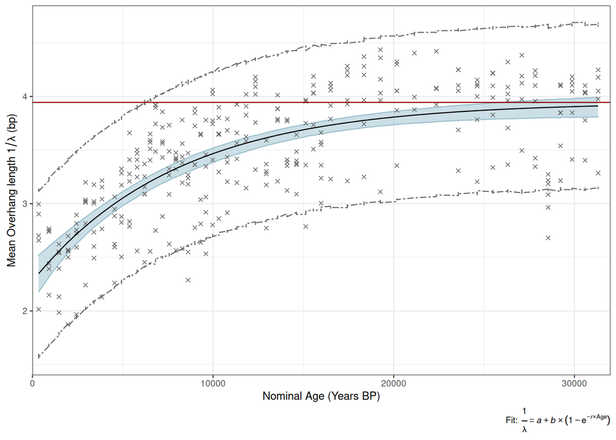

```r
plottable_overhangs$fitted = predict(fit_overhangs)
plottable_overhangs$residual = residuals(fit_overhangs)
plottable_overhangs$CI_lower <- CI_overhangs[, "Sim.2.5%"]
plottable_overhangs$CI_upper <- CI_overhangs[, "Sim.97.5%"]
plottable_overhangs$PI_lower <- PI_overhangs[, "Sim.2.5%"]
plottable_overhangs$PI_upper <- PI_overhangs[, "Sim.97.5%"]


p_lambda= ggplot(plottable_overhangs,aes(x=median_age_yrs_bf_1950))+
  geom_line(aes(y = PI_lower),color='gray40',linetype='twodash')+
  geom_line(aes(y= PI_upper),color='gray40',linetype='twodash')+
  geom_ribbon(aes(x = median_age_yrs_bf_1950,
                  ymin = CI_lower, ymax = CI_upper ),fill = 'lightblue3', color='lightblue3', alpha=0.5) +
geom_point(aes(x=median_age_yrs_bf_1950, y=1/mapdamage_lambda),shape=4, color='gray40')+
geom_line(aes(x=median_age_yrs_bf_1950, y=fitted))+
geom_hline(yintercept=(coef(fit_overhangs)['b'])+coef(fit_overhangs)['a'], colour='darkred')+
theme_bw(base_size = 9)+
scale_x_continuous(expand = c(0,0), limits=c(0,32000))+
labs(
caption = expression("Fit: " ~ frac(1, italic(lambda)) == italic(a) + italic(b) %*% (1 - e^{italic(-r) %*% Age})),
y=expression("Mean Overhang length "* 1/italic(lambda)*" (bp)"),
x = "Nominal Age (Years BP)")
p_lambda
```

### 4.5.4 Characteristic values

```r
#saturation value
coef(fit_overhangs)['b']+coef(fit_overhangs)['a']
```

```
##        b
## 3.944398
```

```r
#time to 99% saturation
(-1/coef(fit_overhangs)['r'])*log(0.01)
```

```
##        r
## 36829.04
```

### 4.5.5 Residuals

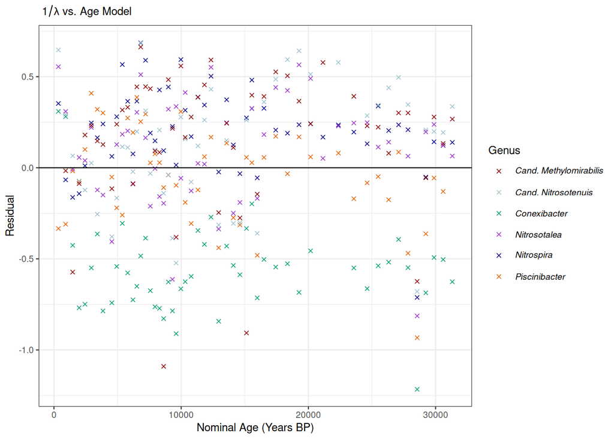

```r
lambda_res=ggplot(plottable_overhangs, aes(x=median_age_yrs_bf_1950, y=residual, color=genus))+
geom_point(shape=4)+
geom_hline(yintercept=0)+
theme_bw(base_size = 9)+
labs(x='Nominal Age (Years BP)', y='Residual', subtitle=expression(~1/italic(lambda)*' vs. Age Model'))+
scale_color_manual("Genus", values =c( "darkred",   "lightblue3",    '#009E73',    "darkorchid",   "blue4",'#E66101'),
                  labels = parse(text = genus_labels))
lambda_res
```

## 4.6 Screening for influence of GC content and cell wall morphology

```r
residuals_overview=list(plottable_delta_s,plottable_mode,plottable_overhangs,plottable_pgeom,plottable_pmax)
```

```r
# Function to summarize a single model data frame by genus
summarize_by_genus <- function(df) {
  df %>%
    group_by(genus) %>%
    summarise(
      median_gc = median(gc_gc, na.rm = TRUE),
      q1_gc = quantile(gc_gc, 0.25, na.rm = TRUE),
      q3_gc = quantile(gc_gc, 0.75, na.rm = TRUE),
      median_resid = median(residual, na.rm = TRUE),
      q1_resid = quantile(residual, 0.25, na.rm = TRUE),
      q3_resid = quantile(residual, 0.75, na.rm = TRUE),
      median_len=median(pydamage_len, na.rm =TRUE),
      sd_len=sd(pydamage_len, na.rm=TRUE),
      n=sum(!is.na(gc_gc)),
      .groups = 'drop'
    ) %>%
    mutate(
      cell_wall = case_when(
        genus == "conexibacter" ~ "gram_pos",
        genus %in% c("nitrosotalea", "candidatus_nitrosotenuis") ~ "archaeon",
        TRUE ~ "gram_neg"
      ))}
# Apply the summarization to all models
genus_summary_list <- lapply(residuals_overview, summarize_by_genus)
```

```r
genus_labels_plain <- c(
  "candidatus_methylomirabilis" = "Cand. Methylomirabilis",
  "candidatus_nitrosotenuis"= "Cand. Nitrosotenuis",
  "conexibacter"= "Conexibacter",
  "nitrosotalea"= "Nitrosotalea",
  "nitrospira"= "Nitrospira",
  "piscinibacter"= "Piscinibacter"
)
make_genus_labels <- function(df) {
  labels <- paste0("italic('",genus_labels_plain[df$genus],"')~'('*italic(n)*' = '*",df$n,"*')'")
  setNames(labels, df$genus)}
```

```
## `height` was translated to `width`.
```

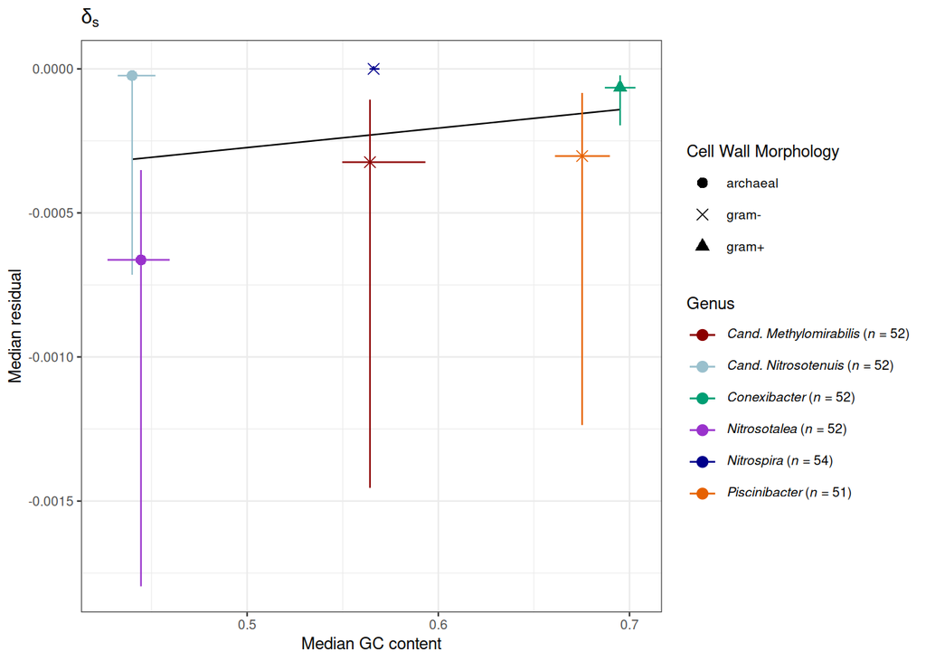

```r
plot_genus_model = function(genus_summary_list) {
  labels = c(expression(italic(delta)[s]), "Mode Fragment Length",expression(1 / italic(lambda)),expression(italic(p)[geom]), expression(italic(p)[max]))

  results = vector("list", length(genus_summary_list))
  for (i in seq_along(genus_summary_list)) {
    df = genus_summary_list[[i]]
    results[[i]] = ggplot(
      df,aes(x = median_gc, y = median_resid, shape = cell_wall, color=genus, group=1)) +
       geom_smooth( method = "lm",formula = y ~ x,se = FALSE, aes(group = 1), color = "black", linewidth = 0.4)+
      geom_point(size = 2.5) +
      geom_errorbar(aes(ymin = q1_resid,  ymax = q3_resid),width = 0) +
      geom_errorbar(aes(xmin = q1_gc,xmax = q3_gc),height = 0) +
      labs(x = "Median GC content",y = "Median residual", title = labels[i]
      ) +
      theme_bw(base_size = 9)+
      #scale_color_manual('Cell Wall Morphology', values = c('gram_pos'='lightblue3','archaeon'='darkred','gram_neg'='gray40' ),labels=c('gram_pos'='gram+','gram_neg'= 'gram-', 'archaeon'='archaeal'))+
      scale_shape_manual('Cell Wall Morphology', values = c('gram_pos'=17,'archaeon'=16,'gram_neg'=4),labels=c('gram_pos'='gram+','gram_neg'= 'gram-', 'archaeon'='archaeal'))+
      scale_color_manual("Genus", values =c( "darkred",   "lightblue3",    '#009E73',    "darkorchid",   "blue4",'#E66101'),
                  labels = parse(text = make_genus_labels(df)))
  }
  return(results)
}
# Apply to all models in your list
results_list_gc = plot_genus_model(genus_summary_list)
results_list_gc[[1]]
```

## 4.7 Screening for influence of reference length

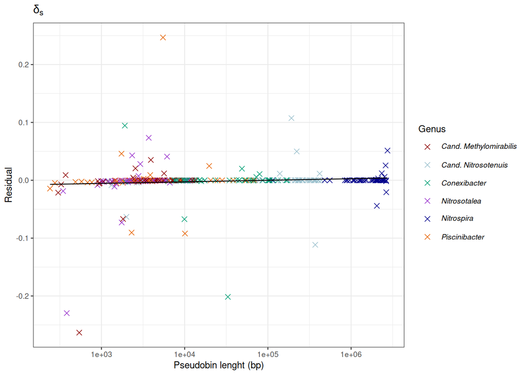

```r
plot_res_vs_len = function(list) {
  labels = c(expression(italic(delta)[s]), "Mode Fragment Length",expression(1 / italic(lambda)),expression(italic(p)[geom]), expression(italic(p)[max]))

  results = vector("list", length(list))
  for (i in seq_along(list)) {
    df = list[[i]]
    results[[i]] = ggplot(
      df,aes(y = residual, x = pydamage_len, color = genus, group=1)) +
      geom_point(size = 2, shape=4) +
      geom_smooth( method = "lm",formula = y ~ x,se = FALSE, aes(group = 1), color='black', linewidth = 0.4)+
      labs(x = "Pseudobin lenght (bp)",y = "Residual", title = labels[i]) +
      theme_bw(base_size = 9)+
     # facet_wrap(~genus)+
      scale_x_log10()+
      scale_color_manual("Genus", values =c( "darkred",   "lightblue3",    '#009E73',    "darkorchid",   "blue4",'#E66101'), labels = parse(text = genus_labels))
  }
  return(results)
}
# Apply to all models in your list
results_list_len = plot_res_vs_len(residuals_overview)
results_list_len[[1]]
```

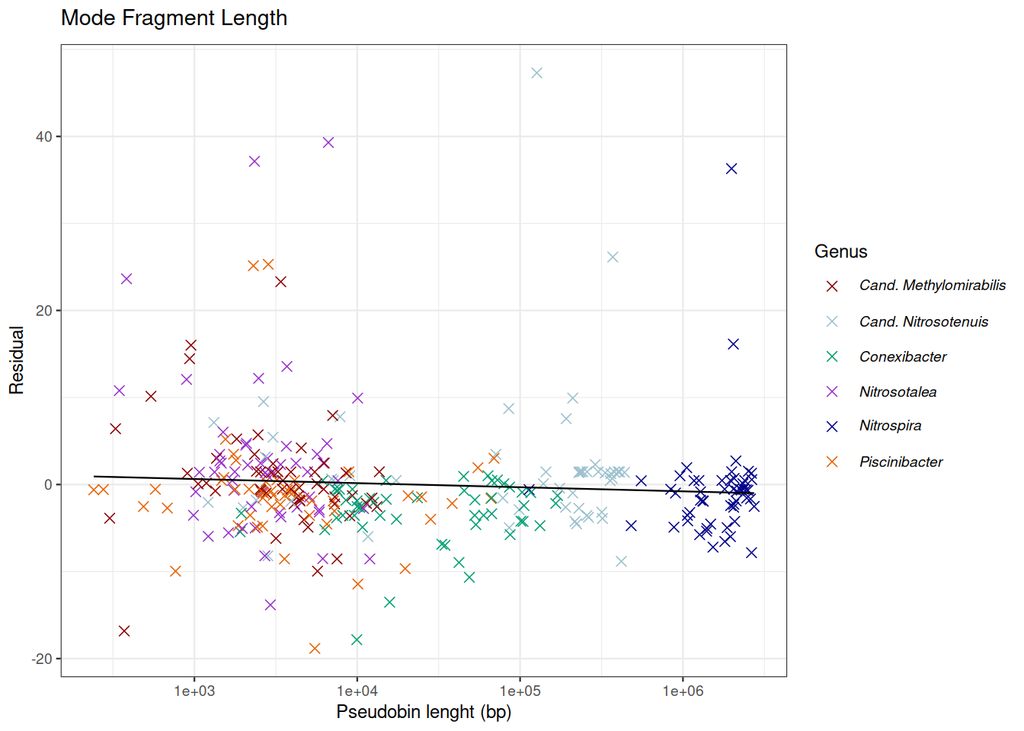

```r
results_list_len[[2]]
```

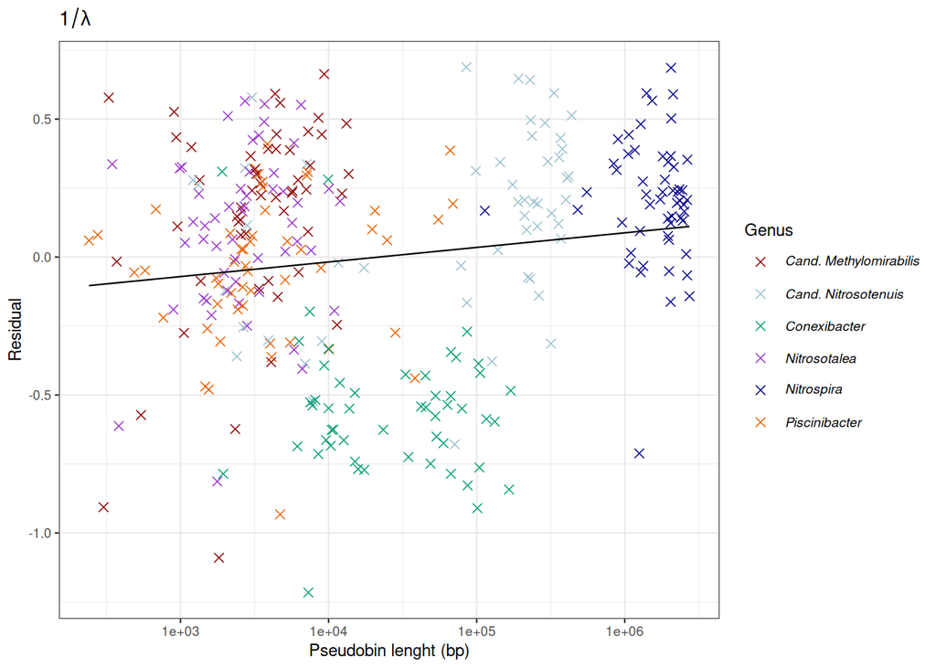

```r
results_list_len[[3]]
```

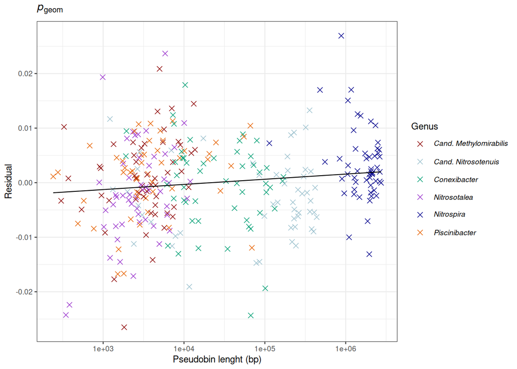

```r
results_list_len[[4]]
```

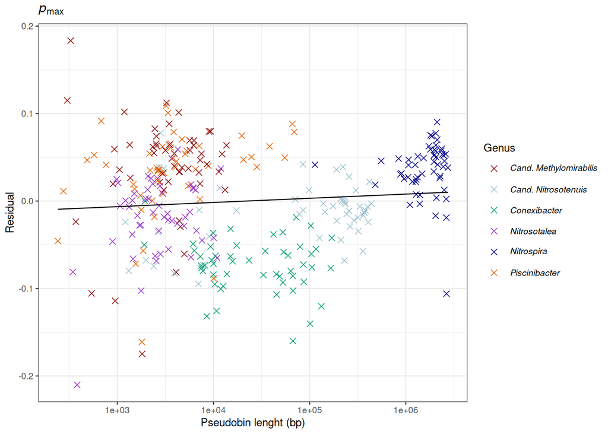

```r
results_list_len[[5]]
```

```r
lm(residual ~ log(pydamage_len), data = plottable_pmax) %>% summary()
```

```
##
## Call:
## lm(formula = residual ~ log(pydamage_len), data = plottable_pmax)
##
## Residuals:
##       Min        1Q    Median        3Q       Max
## -0.201710 -0.039560  0.009468  0.042098  0.192105
##
## Coefficients:
##                    Estimate Std. Error t value Pr(>|t|)
## (Intercept)       -0.020795   0.013182  -1.577    0.116
## log(pydamage_len)  0.002081   0.001277   1.629    0.104
##
## Residual standard error: 0.05812 on 311 degrees of freedom
## Multiple R-squared:  0.008459,   Adjusted R-squared:  0.005271
## F-statistic: 2.653 on 1 and 311 DF,  p-value: 0.1043
```

```r
lm(residual ~ log(pydamage_len), data = plottable_delta_s) %>% summary()
```

```
##
## Call:
## lm(formula = residual ~ log(pydamage_len), data = plottable_delta_s)
##
## Residuals:
##       Min        1Q    Median        3Q       Max
## -0.257249 -0.001122  0.002171  0.003272  0.250247
##
## Coefficients:
##                     Estimate Std. Error t value Pr(>|t|)
## (Intercept)       -0.0134731  0.0071964  -1.872   0.0621 .
## log(pydamage_len)  0.0011705  0.0006974   1.678   0.0943 .
## ---
## Signif. codes:  0 '***' 0.001 '**' 0.01 '*' 0.05 '.' 0.1 ' ' 1
##
## Residual standard error: 0.03173 on 311 degrees of freedom
## Multiple R-squared:  0.008977,   Adjusted R-squared:  0.005791
## F-statistic: 2.817 on 1 and 311 DF,  p-value: 0.09426
```

```r
lm(residual ~ log(pydamage_len), data = plottable_mode) %>% summary()
```

```
##
## Call:
## lm(formula = residual ~ log(pydamage_len), data = plottable_mode)
##
## Residuals:
##     Min      1Q  Median      3Q     Max
## -19.113  -3.172  -0.947   1.431  47.660
##
## Coefficients:
##                   Estimate Std. Error t value Pr(>|t|)
## (Intercept)         2.0478     1.6342   1.253    0.211
## log(pydamage_len)  -0.2049     0.1584  -1.294    0.197
##
## Residual standard error: 7.205 on 311 degrees of freedom
## Multiple R-squared:  0.005355,   Adjusted R-squared:  0.002157
## F-statistic: 1.674 on 1 and 311 DF,  p-value: 0.1966
```

```r
lm(residual ~ log(pydamage_len), data = plottable_pgeom) %>% summary()
```

```
##
## Call:
## lm(formula = residual ~ log(pydamage_len), data = plottable_pgeom)
##
## Residuals:
##        Min         1Q     Median         3Q        Max
## -0.0254799 -0.0045600 -0.0000347  0.0048125  0.0254040
##
## Coefficients:
##                     Estimate Std. Error t value Pr(>|t|)
## (Intercept)       -0.0041092  0.0017678  -2.324   0.0207 *
## log(pydamage_len)  0.0004112  0.0001713   2.400   0.0170 *
## ---
## Signif. codes:  0 '***' 0.001 '**' 0.01 '*' 0.05 '.' 0.1 ' ' 1
##
## Residual standard error: 0.007795 on 311 degrees of freedom
## Multiple R-squared:  0.01819,    Adjusted R-squared:  0.01503
## F-statistic: 5.761 on 1 and 311 DF,  p-value: 0.01697
```

```r
lm(residual ~ log(pydamage_len), data = plottable_overhangs) %>% summary()
```

```
##
## Call:
## lm(formula = residual ~ log(pydamage_len), data = plottable_overhangs)
##
## Residuals:
##      Min       1Q   Median       3Q      Max
## -1.19077 -0.24950  0.08585  0.27780  0.68250
##
## Coefficients:
##                    Estimate Std. Error t value Pr(>|t|)
## (Intercept)       -0.229383   0.086651  -2.647  0.00853 **
## log(pydamage_len)  0.022953   0.008397   2.733  0.00663 **
## ---
## Signif. codes:  0 '***' 0.001 '**' 0.01 '*' 0.05 '.' 0.1 ' ' 1
##
## Residual standard error: 0.3821 on 311 degrees of freedom
## Multiple R-squared:  0.02346,    Adjusted R-squared:  0.02032
## F-statistic: 7.472 on 1 and 311 DF,  p-value: 0.006626
```

# 5. Application of p_max-age-model for absolute age prediction

```r
test_genera_w=test_genera_w[test_genera_w$median_age_yrs_bf_1950 <32000,]
```

## 5.1 Overview of test data

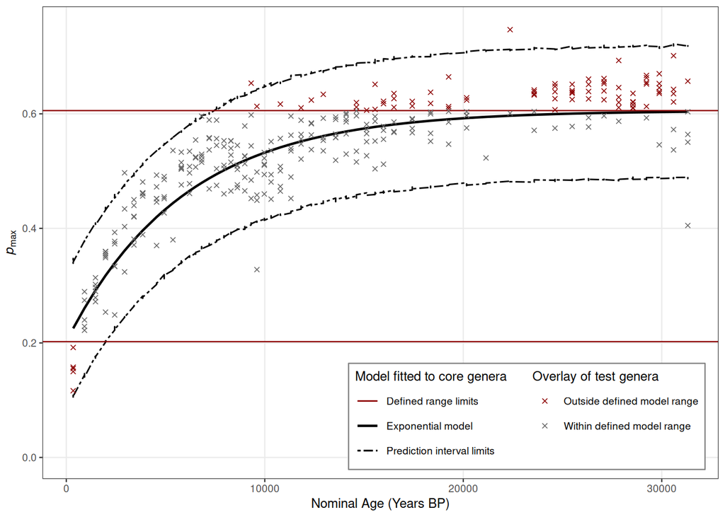

```r
test_genera_w$range_status <- ifelse(
  test_genera_w$pydamage_pmax < coef(fit_pmax)['a'] |
    test_genera_w$pydamage_pmax >coef(fit_pmax)['b']+coef(fit_pmax)['a'],
  "Outside defined model range",
  "Within defined model range"
)

overview <- ggplot(test_genera_w,aes(x = median_age_yrs_bf_1950,y = pydamage_pmax)) +
  #geom_rect(aes(xmin=-Inf,xmax=Inf,ymin=model_lower,ymax=model_upper),fill="grey90") +
  geom_line(data=plottable_pmax,aes(x=median_age_yrs_bf_1950,y=fitted,linetype="Exponential model"),inherit.aes=FALSE,linewidth=0.8) +
  geom_line(data=plottable_pmax,aes(x=median_age_yrs_bf_1950,y=PI_lower,linetype="Prediction interval limits"),inherit.aes=FALSE,linewidth=0.5) +
  geom_line(data=plottable_pmax,aes(x=median_age_yrs_bf_1950,y=PI_upper,linetype="Prediction interval limits"),inherit.aes=FALSE,linewidth=0.5) +
  geom_hline(aes(yintercept=coef(fit_pmax)['a'],linetype="Defined range limits"),color="darkred") +
  geom_hline(aes(yintercept=coef(fit_pmax)['b']+coef(fit_pmax)['a'],linetype="Defined range limits"),color="darkred") +
  geom_point(aes(color=range_status),shape=4) +
  scale_color_manual(name="Overlay of test genera",values=c("Within defined model range"="grey40","Outside defined model range"="darkred")) +
  scale_linetype_manual(name="Model fitted to core genera",values=c("Exponential model"="solid","Prediction interval limits"="twodash","Defined range limits"="solid")) +
  labs(x="Nominal Age (Years BP)",y=expression(italic(p)[max])) +
  theme_bw(base_size=9) +
  theme(panel.grid.minor=element_blank(),legend.position = c(0.98, 0.02),
  legend.justification = c(1, 0),legend.box="horizontal",legend.box.just="top",legend.direction = "vertical",legend.background = element_rect(fill = NA),legend.box.background = element_rect(
    fill = "white",
    colour = "grey50",
    linewidth = 0.4
  ))+
  ylim(c(0,0.75))
overview
```

```r
plottable_overview <- rbind(data.frame(
    source = "test_genera_overlay",
    age = test_genera_w$median_age_yrs_bf_1950,
    pmax = test_genera_w$pydamage_pmax,
    fitted = NA,
    PI_lower = NA,
    PI_upper = NA,
    defined_lower = NA,
    defined_upper = NA,
    range_status = test_genera_w$range_status
  ),
  data.frame(
    source = "core_genera_model",
    age = plottable_pmax$median_age_yrs_bf_1950,
    pmax = NA,
    fitted = plottable_pmax$fitted,
    PI_lower = plottable_pmax$PI_lower,
    PI_upper = plottable_pmax$PI_upper,
    defined_lower = coef(fit_pmax)['a'],
    defined_upper = coef(fit_pmax)['b']+coef(fit_pmax)['a'],
    range_status = NA
  )
)
```

Pseudobins exceeding the range of the model:

```r
sum(test_genera_w$pydamage_pmax >=coef(fit_pmax)['b']+coef(fit_pmax)["a"]|test_genera_w$pydamage_pmax <= coef(fit_pmax)["a"] )
```

```
## [1] 80
```

## 5.2 Model inversion and age prediction

```r
invert_age = function(pmax, a, b, r) {
  # Return NA if pmax outside model range
  if(pmax <= a | pmax >= (a + b)) return(NA)
  -1 / r * log(1 - (pmax - a)/b)
}
```

```r
predict_age_from_pmax <- function(df, pmax_col, model, B = 1000, seed = 1963) {
  set.seed(seed)

  # Extract parameter estimates and covariance
  params_est = coef(model)
  cov_mat = vcov(model)
  sigma_resid = summary(model)$sigma

  # Prepare storage vectors
  n = nrow(df)
  age_point = numeric(n)
  age_ci_lower <- numeric(n)
  age_ci_upper <- numeric(n)
  age_pi_lower = numeric(n)
  age_pi_upper = numeric(n)
  age_pi_bootstrap = vector("list", n)

  for(i in 1:n) {
    pmax = df[[pmax_col]][i]
#Point estimate
    age_point[i] = invert_age(pmax, params_est["a"], params_est["b"], params_est["r"])

#CI: parametric bootstrap without residual noise
    param_samples <- mvrnorm(B, mu = params_est, Sigma = cov_mat)
    age_boot_ci <- sapply(1:B, function(j) {
      invert_age(pmax, param_samples[j, "a"], param_samples[j, "b"], param_samples[j, "r"])
    })
    age_boot_ci <- age_boot_ci[!is.na(age_boot_ci)]
    age_ci_lower[i] <- quantile(age_boot_ci, 0.025)
    age_ci_upper[i] <- quantile(age_boot_ci, 0.975)
#PI: parametric bootstrap with residual noise
    param_samples = mvrnorm(B, mu = params_est, Sigma = cov_mat)
    age_boot_pi = sapply(1:B, function(j) {
      a_j = param_samples[j, "a"]
      b_j = param_samples[j, "b"]
      r_j = param_samples[j, "r"]
# simulate new noisy observation
      y_j = rnorm(1, mean = pmax, sd = sigma_resid)
      invert_age(y_j, a_j, b_j, r_j)
    })
    age_boot_pi = age_boot_pi[!is.na(age_boot_pi)]
    age_pi_lower[i] = quantile(age_boot_pi, 0.025)
    age_pi_upper[i] = quantile(age_boot_pi, 0.975)
    age_pi_bootstrap[[i]] = age_boot_pi
  }

# Append results to data frame
  df$age_point = age_point
  df$age_CI_lower <- age_ci_lower
  df$age_CI_upper <- age_ci_upper
  df$age_PI_lower = age_pi_lower
  df$age_PI_upper = age_pi_upper
  df$age_PI_bootstrap = age_pi_bootstrap
  return(df)
}
```

```r
test_genera_dated = predict_age_from_pmax(test_genera_w, "pydamage_pmax", fit_pmax, B = 2000)
head(test_genera_dated)
```

| sample | genus | sample_name | dft_interval | min_age_yrs_bf_1950 | max_age_yrs_bf_1950 | mean_age_yrs_bf_1950 | median_age_yrs_bf_1950 | ImageJ_measurement_cm | Rounded_Length | DFT | Rounded_DFT | Library | qPCRcopies_per_uL | mass_mg | EDTA_fractions | gc_gc | pydamage_pmin | pydamage_pmin_SD | pydamage_pmax | pydamage_pmax_SD | pydamage_p | pydamage_p_SD | pydamage_nb_contigs | pydamage_nb_reads | pydamage_len | mapdamage_delta_d | mapdamage_delta_s | mapdamage_lambda | compute_length_mode | … |
| --- | --- | --- | --- | --- | --- | --- | --- | --- | --- | --- | --- | --- | --- | --- | --- | --- | --- | --- | --- | --- | --- | --- | --- | --- | --- | --- | --- | --- | --- | --- |
| TDM033 | immundisolibacter | TDM033 | (31.2,32.2] | 13852 | 14347 | 14099.6 | 14100 | 1.05 | 1 | 32.25 | 33 | TDM033.A0401 | 1790000 | 4672.2 | 3 | 0.6263483 | 0.01975000 | 0.003593976 | 0.52975 | 0.03185776 | 0.4865000 | 0.051552562 | 4 | 24934 | 4691 | 0.0008643562 | 0.9997803 | 0.3008634 | 33 | … |
| TDM033 | sulfuritalea | TDM033 | (31.2,32.2] | 13852 | 14347 | 14099.6 | 14100 | 1.05 | 1 | 32.25 | 33 | TDM033.A0401 | 1790000 | 4672.2 | 3 | 0.6741087 | 0.01383333 | 0.008542053 | 0.59050 | 0.02910498 | 0.4491667 | 0.034959500 | 6 | 10450 | 4582 | 0.0001064086 | 0.9996661 | 0.2973399 | 35 | … |
| TDM033 | desertibaculum | TDM033 | (31.2,32.2] | 13852 | 14347 | 14099.6 | 14100 | 1.05 | 1 | 32.25 | 33 | TDM033.A0401 | 1790000 | 4672.2 | 3 | 0.6512828 | 0.01333333 | 0.007023769 | 0.60100 | 0.06579514 | 0.3996667 | 0.043015501 | 3 | 6163 | 2037 | 0.0002741371 | 0.9994030 | 0.2958064 | 36 | … |
| TDM033 | sulfuricaulis | TDM033 | (31.2,32.2] | 13852 | 14347 | 14099.6 | 14100 | 1.05 | 1 | 32.25 | 33 | TDM033.A0401 | 1790000 | 4672.2 | 3 | 0.6394828 | 0.02650000 | 0.002121320 | 0.59850 | 0.02192031 | 0.5270000 | 0.005656854 | 2 | 3591 | 1680 | 0.0160777691 | 0.9988635 | 0.2920832 | 36 | … |
| TDM033 | nitrosospira | TDM033 | (31.2,32.2] | 13852 | 14347 | 14099.6 | 14100 | 1.05 | 1 | 32.25 | 33 | TDM033.A0401 | 1790000 | 4672.2 | 3 | 0.6461697 | 0.01550000 | 0.002121320 | 0.58600 | 0.01979899 | 0.4160000 | 0.046669048 | 2 | 14682 | 2170 | 0.0004897315 | 0.9996878 | 0.2775564 | 36 | … |
| TDM033 | nitrosopumilus | TDM033 | (31.2,32.2] | 13852 | 14347 | 14099.6 | 14100 | 1.05 | 1 | 32.25 | 33 | TDM033.A0401 | 1790000 | 4672.2 | 3 | 0.4737319 | 0.02200000 | NA | 0.56500 | NA | 0.4580000 | NA | 1 | 2969 | 1104 | 0.0135645234 | 0.9974029 | 0.3087723 | 36 | … |